# Case Study 2

Manuela Giansante & Lucia Camenisch

02 April 2023

```r
library(data.table)      # data.table type
library(tidyr)           # gather()
library(kableExtra)      # kables for html document
library(naniar)          # vis_miss()
library(corrplot)        # corrplot()
library(caret)           # findCorrelation()
library(REdaS)           # KMOS(), bart_spher()
library(psych)           # KMO(), fa(), principal()
# library(pastecs)
# library(dplyr)
# library(rcompanion)
# library(GPArotation)
# library(nFactors)
# library(knitr)
```

We start by loading both data files.

```r
descriptions <- fread("Data File_Case Study_Factor Analysis_Variables.csv")
df <- read.csv("Data File_Case_Study_Factor Analysis_MD.csv")
```

We select only the relevant columns which correspond to question numbers `qd1` to `qd33` inside `df`.

```r
df1 <- df[,c(9:41)]
```

We check for missing values.

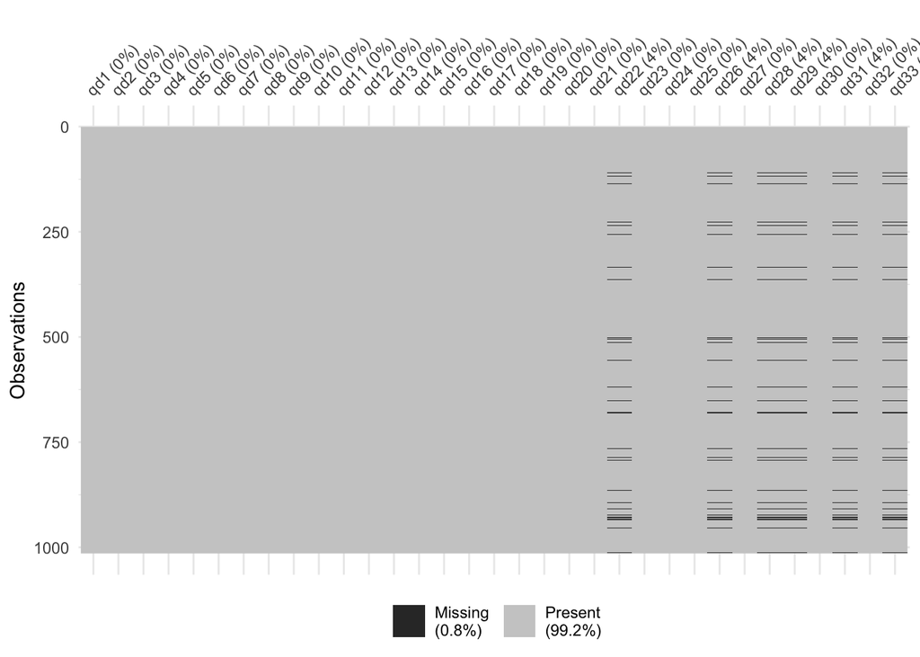

```r
vis_miss(df1)
```

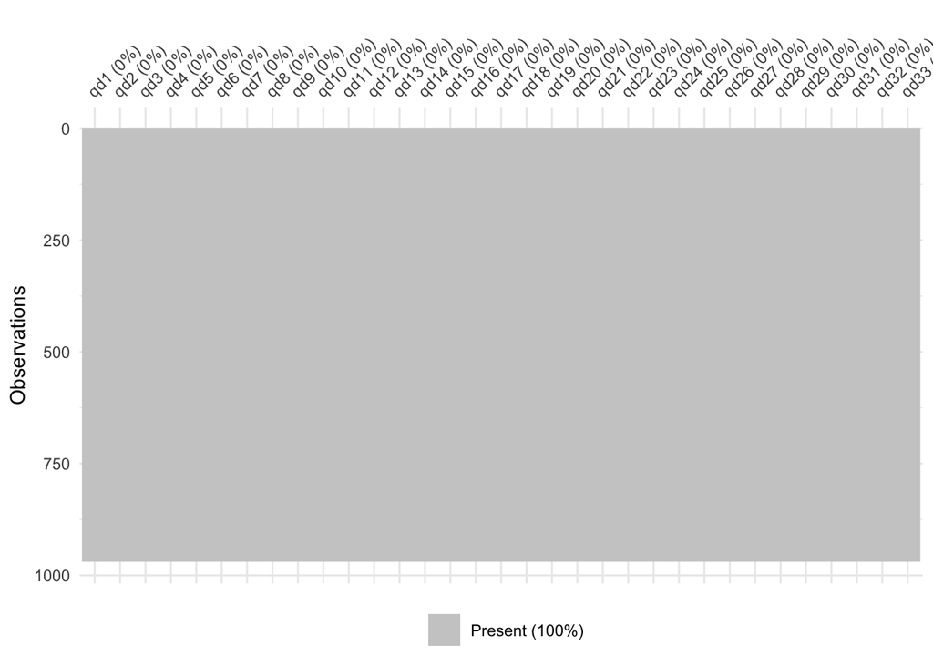

```r
df1 <- na.omit(df1)
vis_miss(df1)
```

Now, our data frame `df1` has no more missing values.

# 1 Orthogonal Factor Analysis

## 1.1 Inspect the correlation matrix.

We compute the correlation matrix and plot it.

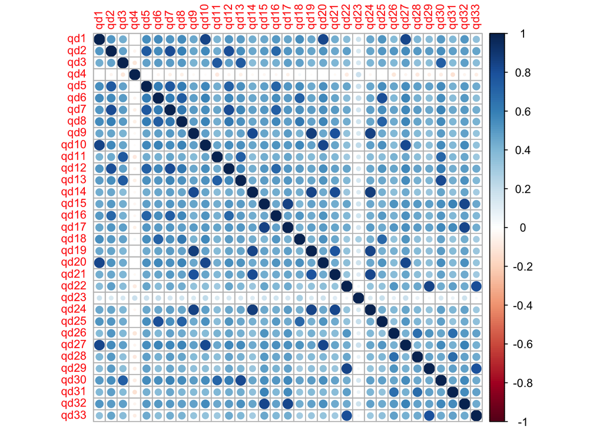

```r
raqMatrix <- cor(df1)
corrplot(raqMatrix, tl.cex = 0.8)
```

We can see some strong correlations, indicated by bigger and darker blue dots, between different questions. Furthermore, we notice that `qd4` and `qd23` seem to be the only two items with low correlations with all the other items. They are standalone items.

A strong correlation between two variables is most likely a signal of redundancy. In regards to the correlation plot above, there are not very clear patterns, but we can observe some variables are highly correlated between one another, which is good since we want to perform a factor analysis. More precisely, we are interested in the underlying factors causing those variables to move the way that they move. A weaker correlation indicates that there are different factors affecting the variables, meaning they do not describe the same domain.

Listed below are the variables displaying higher correlation, with a selected threshold of 0.65.

```r
n = nrow(raqMatrix)
for (i in 1:(n-1)) {
  for (j in (i+1):n) {
    if (raqMatrix[i, j] >= 0.65) {
      print(paste(colnames(df1)[i],
                  "and",
                  colnames(df1)[j],
                  "have a correlation of",
                  round(raqMatrix[i, j], 2)))
    }
  }
}
```

```
## [1] "qd1 and qd10 have a correlation of 0.84"
## [1] "qd1 and qd20 have a correlation of 0.84"
## [1] "qd1 and qd27 have a correlation of 0.84"
## [1] "qd2 and qd5 have a correlation of 0.76"
## [1] "qd2 and qd7 have a correlation of 0.82"
## [1] "qd2 and qd12 have a correlation of 0.81"
## [1] "qd2 and qd16 have a correlation of 0.69"
## [1] "qd3 and qd11 have a correlation of 0.76"
## [1] "qd3 and qd13 have a correlation of 0.76"
## [1] "qd3 and qd30 have a correlation of 0.74"
## [1] "qd5 and qd7 have a correlation of 0.76"
## [1] "qd5 and qd12 have a correlation of 0.73"
## [1] "qd5 and qd16 have a correlation of 0.71"
## [1] "qd6 and qd8 have a correlation of 0.74"
## [1] "qd6 and qd18 have a correlation of 0.73"
```

[output cut: 31 more lines]

```r
rm(i, j, n)
```

This allows us to separate the questionnaire items into clusters by grouping together variables which are highly correlated. We can obtain exactly the same groups by using the `hclust` option when plotting the correlation matrix. Rows and columns are swapped so items who are highly correlated can be side by side.

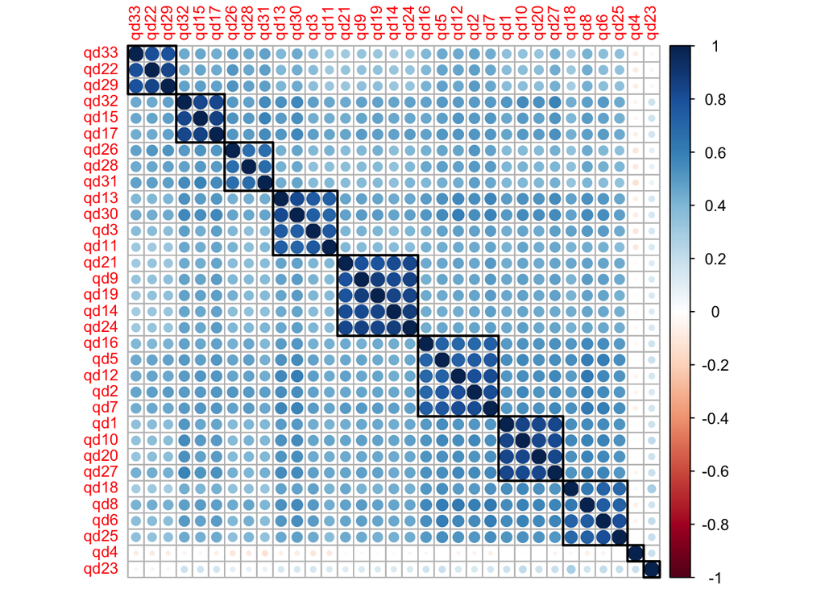

```r
corrplot(raqMatrix, order = 'hclust', tl.cex = 0.8, addrect = 10)
```

The clustering of the correlation matrix with 10 clusters and our grouping with threshold at 0.65 give the same results. We get the following 10 different groups:

- Items 1, 10, 20 and 27, all related to aesthetics;
- Items 2, 5, 7, 12 and 16, all related to performance;
- Items 3, 11, 13 and 30, all related to ease of use;
- Items 6, 8, 18 and 25, all related to features;
- Items 9, 14, 19, 21 and 24, all related to serviceability;
- Items 15, 17 and 32, all related to quality of materials;
- Items 22, 29 and 33, all related to flawlessness;
- Items 26, 28 and 31, all related to durability;
- Item 4, related to distinctiveness;
- Item 23, related to prestige.

This grouping is quite close to quality dimensions defined in the literature (see Table 1 of the assignment pdf). The differences would be the presence of a construct about the quality of materials, which is not listed in the dimensions of quality, and the fact that questions 4 and 23 should reflect the same underlying construct, “Distinctiveness/Prestige”, but it does not seem to be the case from experimental data, as the two variables are very weekly correlated.

## 1.2 Check whether the data set and all of its variables are suitable for factor analysis.

To make sure that our data is suitable for Factor Analysis, we want to test to what extent our variables are correlated to one another. To further the analysis we measure the Sampling Adequacy based on the **Kaiser-Meyer-Olking criterion**:

```r
#Kaiser-Meyer-Olkin Statistics
KMO(df1)
```

```
## Kaiser-Meyer-Olkin factor adequacy
## Call: KMO(r = df1)
## Overall MSA =  0.96
## MSA for each item =
##  qd1  qd2  qd3  qd4  qd5  qd6  qd7  qd8  qd9 qd10 qd11 qd12 qd13 qd14 qd15 qd16
## 0.96 0.97 0.96 0.64 0.98 0.96 0.97 0.98 0.96 0.97 0.96 0.97 0.96 0.96 0.95 0.98
## qd17 qd18 qd19 qd20 qd21 qd22 qd23 qd24 qd25 qd26 qd27 qd28 qd29 qd30 qd31 qd32
## 0.95 0.97 0.96 0.97 0.97 0.93 0.90 0.96 0.96 0.97 0.97 0.96 0.93 0.97 0.96 0.96
## qd33
## 0.95
```

The KMO test measures the proportion of variance between variables which can be attributed to common variance. It takes values between 0 and 1, meaning that higher values of the test indicate that a variable is suitable for factor analysis. The measurement is computed with the following formula:
$$MO_j=\frac{\sum_{i\neq
j}r^2_{ij}}{\sum_{i \neq j} r^2_{ij}+\sum_{i\neq j}p^2_{ij}}$$
where $r_{ij}$ is the correlation coefficient of the variables indexed by $i$ and $j$, and $p_{ij}$ is the partial correlation coefficient of those variables.

Our KMO mean value amounts to 0.96 which indicates that in average variables are well suited for factor analysis. The individual MSA values of variables except for `qd4` are all above 0.9, which corresponds to “marvelous” in correspondence with Kaiser’s nomenclature. The value of `qd4` is considered as “mediocre”. We must look out for it in the next steps.

We will also take a look at the diagonal of the anti-image correlation matrix. This gives us the proportion of a variable’s variance that cannot be explained by any other variable.

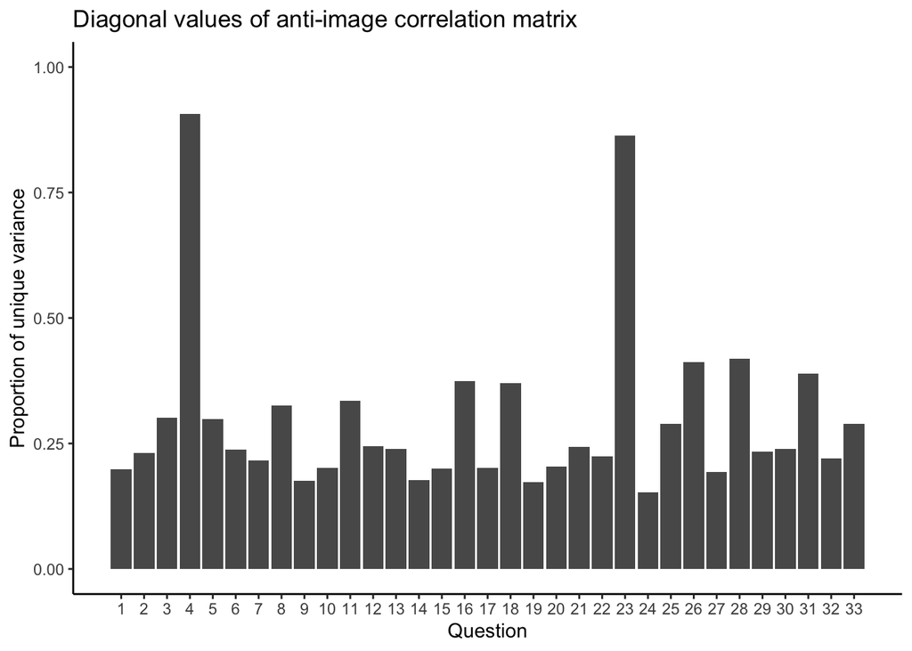

```r
# we use the KMO function from the psych package to retrieve the anti-image cor mat
anti_mat_diag = data.frame("Question" = 1:33,
                           "UniqueVar" = diag(KMO(df1)$ImCov))

ggplot(data = anti_mat_diag, aes(x = Question, y = UniqueVar)) +
  geom_col() +
  theme_classic() +
  scale_x_continuous(breaks = seq(1, 33, 1)) +
  scale_y_continuous(limits = c(0,1)) +
  labs(title = "Diagonal values of anti-image correlation matrix",
       y = "Proportion of unique variance")
```

```r
rm(anti_mat_diag)
```

In our case, `qd4` and `qd23` have values above 0.5, indicating that their topics have not been sufficiently covered in the questionnaire. They clearly result as outliers compared to all the other variables.

Another way to judge whether our data is suitable for factor analysis would be **Bartlett’s test**. The null hypothesis of this test is that the sample originates from a population, where all variables are uncorrelated, or in other words that the correlation matrix equals the identity matrix. The test is more suited for cases in which each variable has less than 5 observations, because it is very sensitive within large samples and thus might not be a good fit for us.

The test results highly significant, meaning we can reject the null hypothesis, the data is fit for factor analysis.

```r
bart_spher(df1)
```

```
##  Bartlett's Test of Sphericity
##
## Call: bart_spher(x = df1)
##
##      X2 = 30857.911
##      df = 528
## p-value < 2.22e-16
```

After having considered all the above elements, this data set looks suitable for factor analysis. The only two items we need to pay special attention to are `qd4` and `qd23`, as they might not be as well suited as the rest.

## 1.3 Run principal axis factoring (PAF) and use varimax rotation.

Principal axis factoring is implemented with the `fa` function from `psych` package.

The number of underlying factors has to be specified inside the function. If we try to input a number of factors greater than 13, `fa` returns an error. Thus, we test options for models going from 1 factor to 13 and record each time some criteria aimed at helping select the best model.

Those criterias are:

- `fit`, which measures how well the factor model reproduces the correlation matrix;
- `objective`, which is the value of the function that is minimized by a maximum likelihood procedure;
- `rms`, which is the sum of the squared off-diagonal residuals divided by the degrees of freedom;
- `crms`, which is the RMS adjusted for degrees of freedom;
- `TLI`, which is the Tucker Lewis Index of factoring reliability;
- `BIC`, which is the Bayesian information criterion.

A good model exhibits high values of `fit` and `TLI`, and low values of the others.

```r
# we initiate and empty dataframe which will record our criteria values
fit_df <- matrix(nrow = 13, ncol = 6)
colnames(fit_df) <- c("fit", "objective", "rms", "crms", "TLI", "BIC")
fit_df <- as.data.frame(fit_df)

# we compute the factor analysis for nfactors between 1 and 13 and record criteria results in fit_df
for (i in 1:13) {
  FA <- fa(df1, nfactors = i, rotate = "varimax", fm = "pa")
  fit_df[i, 1] <- FA$fit
  fit_df[i, 2] <- FA$objective
  fit_df[i, 3] <- FA$rms
  fit_df[i, 4] <- FA$crms
  fit_df[i, 5] <- FA$TLI
  fit_df[i, 6] <- FA$BIC
}

rm(i, FA)
```

Now, we can plot the values of each criteria with respect to the number of factors.

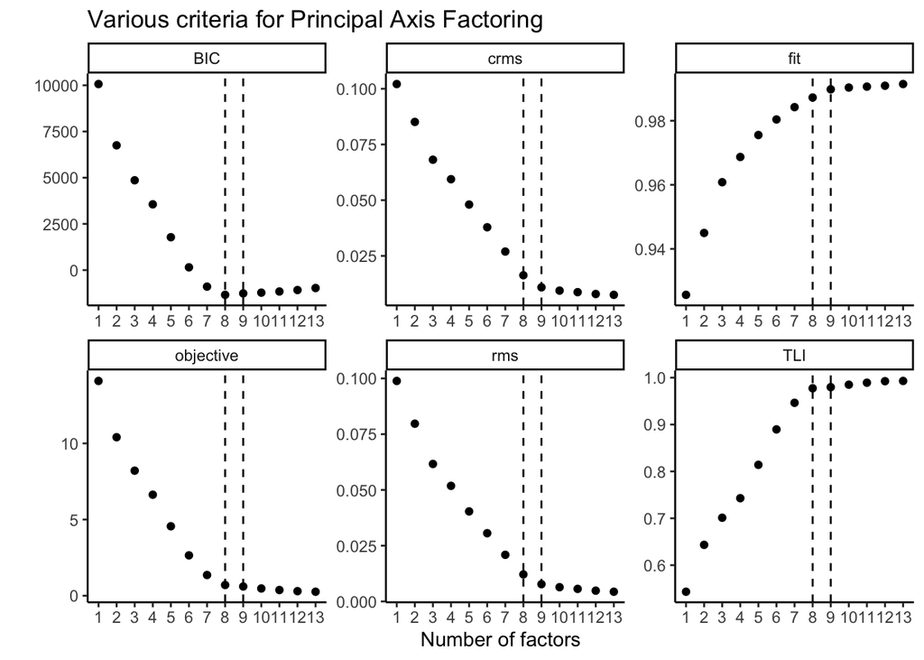

```r
fit_df %>% gather() %>%
  ggplot(aes(x = rep(1:13, ncol(fit_df)), y = value)) +
  facet_wrap(~ key, scales = "free") +
  geom_point() +
  theme_classic() +
  scale_x_continuous(breaks = seq(1, 13, 1)) +
  geom_vline(xintercept = 8, linetype = "dashed") +
  geom_vline(xintercept = 9, linetype = "dashed") +
  labs(title = "Various criteria for Principal Axis Factoring",
       x = "Number of factors",
       y = "")
```

The dashed lines designate the number of factors which seem the most appropriate for our data. The improvement in criteria for numbers of factors greater than 9 is much slower and less significant. Depending on the criterion, we would choose 8 or 9, so we will test both models with and without including questions 4 and 23, since our exploratory analysis of the data indicated that those two variables probably will not be loaded onto factors, as they are standalone.

```r
FA8 <- fa(df1, nfactors = 8, rotate = "varimax", fm = "pa")
FA8_423 <- fa(df1[, -c(4, 23)], nfactors = 8, rotate = "varimax", fm = "pa")
FA9 <- fa(df1, nfactors = 9, rotate = "varimax", fm = "pa")
FA9_423 <- fa(df1[, -c(4, 23)], nfactors = 9, rotate = "varimax", fm = "pa")
```

We examine the factor loadings of each model, using a plot similar to the correlation plot to quickly visualize them.

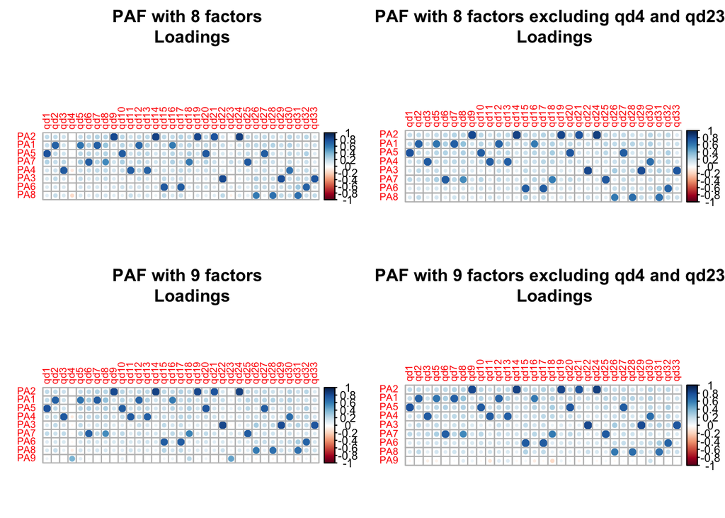

```r
par(mfrow = c(2,2))
corrplot(t(FA8$loadings),
         tl.cex = 0.7,
         title = "PAF with 8 factors \n Loadings",
         mar = c(0, 1, 3, 0))
corrplot(t(FA8_423$loadings),
         tl.cex = 0.7,
         title = "PAF with 8 factors excluding qd4 and qd23 \n Loadings",
         mar = c(0, 1, 3, 0))
corrplot(t(FA9$loadings),
         tl.cex = 0.7,
         title = "PAF with 9 factors \n Loadings",
         mar = c(0, 1, 3, 0))
corrplot(t(FA9_423$loadings),
         tl.cex = 0.7,
         title = "PAF with 9 factors excluding qd4 and qd23 \n Loadings",
         mar = c(0, 1, 3, 0))
```

```r
par(mfrow = c(1,1))
```

We remark the following:

- In `FA8`, questions 4 and 23 aren’t loaded on any factor. Each other variable is clearly loaded on a unique factor.
- In `FA8_423`, each variable is clearly loaded on one factor like before, since we deleted the two variables which weren’t associated on any of the 8 factors. If we decide to keep a model with 8 factors, we could delete `qd4` and `qd23` as they will not be loaded onto a factor in any case.
- In `FA9`, questions 4 and 23 are loaded onto one factor together and all other variables are loaded on one of the 8 other factors. The loadings of `qd4` and `qd23` are the lowest however, at 0.414 and 0.474 respectively.
- In `FA9_423`, the ninth factor has no variable loaded on it, as we have deleted questions 4 and 23 and the other items are arranged on 8 factors. This model is not appropriate for the data and should be discarded.

In summary, there are two possible models:

- A model with 8 factors which does not include `qd4` and `qd23`;
- A model with 9 factors in which `qd4` and `qd23` are loaded onto a factor together.

We discard `FA8` and `FA9_423` and display the numerical loadings greater than 0.3 of the two remaining models.

```r
rm(FA8, FA9_423)

print(FA8_423$loadings, cutoff = 0.3, sort = TRUE)
```

```
##
## Loadings:
##      PA2   PA1   PA5   PA4   PA3   PA7   PA6   PA8
## qd9  0.827
## qd14 0.851
## qd19 0.832
## qd21 0.785
## qd24 0.860
## qd2        0.723
## qd5        0.645
## qd7        0.738
## qd12       0.711
## qd16       0.616
## qd1              0.797
## qd10             0.749
## qd20             0.772
## qd27             0.747
## qd3                    0.759
## qd11                   0.749
## qd13                   0.739
## qd30                   0.677
## qd22                         0.837
## qd29                         0.813
## qd33                         0.780
## qd6                                0.741
## qd8        0.341                   0.558
## qd18                               0.601
## qd25                               0.762
## qd15                                     0.749
## qd17                                     0.744
## qd32                                     0.715
## qd26                                           0.620
## qd28                                           0.672
## qd31                                           0.660
##
##                  PA2   PA1   PA5   PA4   PA3   PA7   PA6   PA8
## SS loadings    4.569 3.577 3.404 3.121 2.781 2.675 2.324 1.935
## Proportion Var 0.147 0.115 0.110 0.101 0.090 0.086 0.075 0.062
## Cumulative Var 0.147 0.263 0.373 0.473 0.563 0.649 0.724 0.787
```

```r
print(FA9$loadings, cutoff = 0.3, sort = TRUE)
```

```
##
## Loadings:
##      PA2    PA1    PA5    PA4    PA3    PA7    PA6    PA8    PA9
## qd9   0.830
## qd14  0.853
## qd19  0.834
## qd21  0.788
## qd24  0.862
## qd2          0.727
## qd5          0.649
## qd7          0.743
## qd12         0.716
## qd16         0.619
## qd1                 0.796
## qd10                0.747
## qd20                0.772
## qd27                0.748
## qd3                        0.761
## qd11                       0.750
## qd13                       0.736
## qd30                       0.674
## qd22                              0.835
## qd29                              0.813
## qd33                              0.779
## qd6                                      0.735
## qd8          0.352                       0.559
## qd18                                     0.589
## qd25                                     0.746
## qd15                                            0.749
## qd17                                            0.743
## qd32                                            0.712
## qd26                                                   0.616
## qd28                                                   0.661
## qd31                                                   0.653
## qd4                                                           0.414
## qd23                                                          0.474
##
##                  PA2   PA1   PA5   PA4   PA3   PA7   PA6   PA8   PA9
## SS loadings    4.632 3.667 3.412 3.134 2.783 2.559 2.320 1.882 0.517
## Proportion Var 0.140 0.111 0.103 0.095 0.084 0.078 0.070 0.057 0.016
## Cumulative Var 0.140 0.251 0.355 0.450 0.534 0.612 0.682 0.739 0.755
```

We notice that the factors created by PAF are the same groups we identified with our clustering of the correlation matrix. In both models, `qd8`, which was grouped with the features construct, is partially loaded onto factor PA1, which corresponds to the performance construct. We fetch its description.

```r
descriptions[name %in% "qd8", ]
```

```
##    name                                                         Label
## 1:  qd8 the extra features offered in my smartphone  usually function
```

Some people answering might consider not only extra features but any features of their smartphone and evaluate their performance, i.e. how they function. This might explain why `qd8` is partially loaded onto the performance construct. However, it remains mainly loaded onto the features construct, with a value of 0.558 or 0.559 according to the model.

In model `FA9`, loadings of `qd4` and `qd23` on their factor are the weakest of all “main” loadings. This could indicate that keeping `qd4` and `qd23` might not be totally appropriate and is up to discussion.

When looking at the communalities of our models, we get the following results:

```r
sort(FA8_423$communality)
```

```
##      qd18      qd16      qd26      qd28       qd8      qd31      qd11       qd5
## 0.6266777 0.6402010 0.6551763 0.6849299 0.6855023 0.7001560 0.7169741 0.7224583
##      qd33       qd3      qd21      qd30      qd12      qd25       qd2      qd13
## 0.7612886 0.7629531 0.7706646 0.7756551 0.7829168 0.8004648 0.8052923 0.8058405
##      qd32      qd29      qd10       qd7      qd20      qd27       qd6       qd9
## 0.8295319 0.8312862 0.8333518 0.8357790 0.8360730 0.8390860 0.8392665 0.8406325
##      qd19      qd14       qd1      qd15      qd22      qd17      qd24
## 0.8435205 0.8526145 0.8538126 0.8560076 0.8572538 0.8573949 0.8826324
```

```r
sort(FA9$communality)
```

```
##       qd4      qd23      qd16      qd26      qd18      qd28       qd8      qd31
## 0.1860315 0.2740969 0.6409344 0.6570266 0.6693727 0.6805048 0.6954544 0.7034429
##      qd11       qd5      qd33       qd3      qd21      qd30      qd12      qd25
## 0.7194675 0.7286179 0.7617402 0.7666282 0.7707646 0.7740474 0.7848395 0.7916454
##      qd13       qd2      qd32      qd29      qd10      qd20       qd7      qd27
## 0.8026750 0.8047862 0.8286370 0.8325405 0.8333801 0.8365920 0.8368335 0.8404022
##       qd9       qd6      qd19      qd14       qd1      qd22      qd17      qd15
## 0.8405512 0.8421117 0.8439347 0.8525442 0.8531018 0.8557809 0.8564535 0.8588101
##      qd24
## 0.8825049
```

This further indicates that questions 4 and 23 might not be appropriate in for factor analysis, as their communalities inside `FA9` are extremely low. The communality of an item is the sum of the squared factor loadings for that item. It measures the proportion of the item’s variance that can be explained by the underlying factors.

We observe the scree plots of our two models.

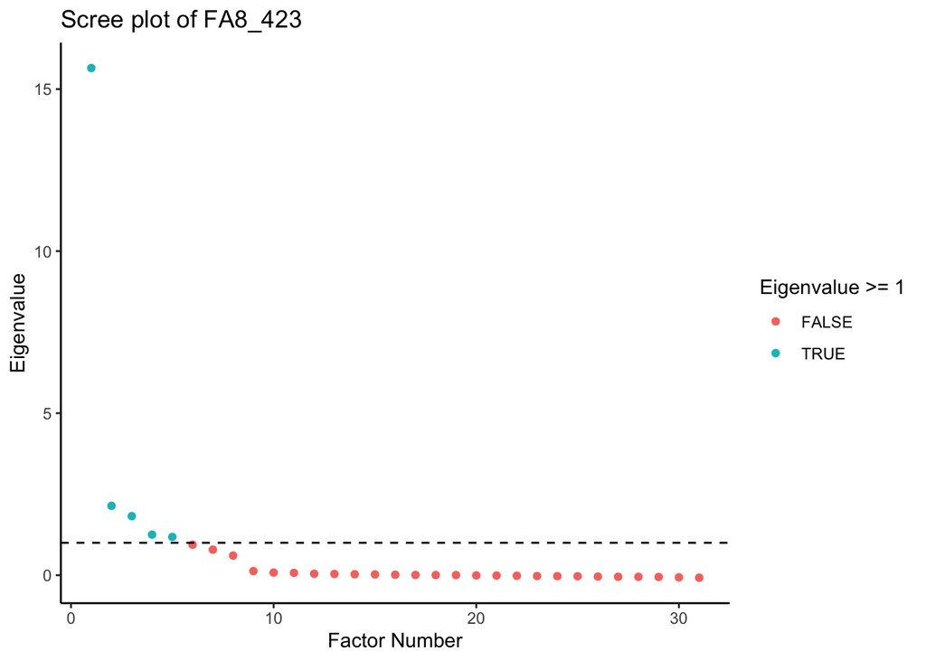

```r
ggplot(mapping = aes(x = 1:length(FA8_423$values),
                     y = FA8_423$values,
                     color = (FA8_423$values >= 1))) +
  geom_point() +
  geom_hline(yintercept = 1, linetype = "dashed") +
  theme_classic() +
  labs(title = "Scree plot of FA8_423",
       x = "Factor Number",
       y = "Eigenvalue",
       color = "Eigenvalue >= 1")
```

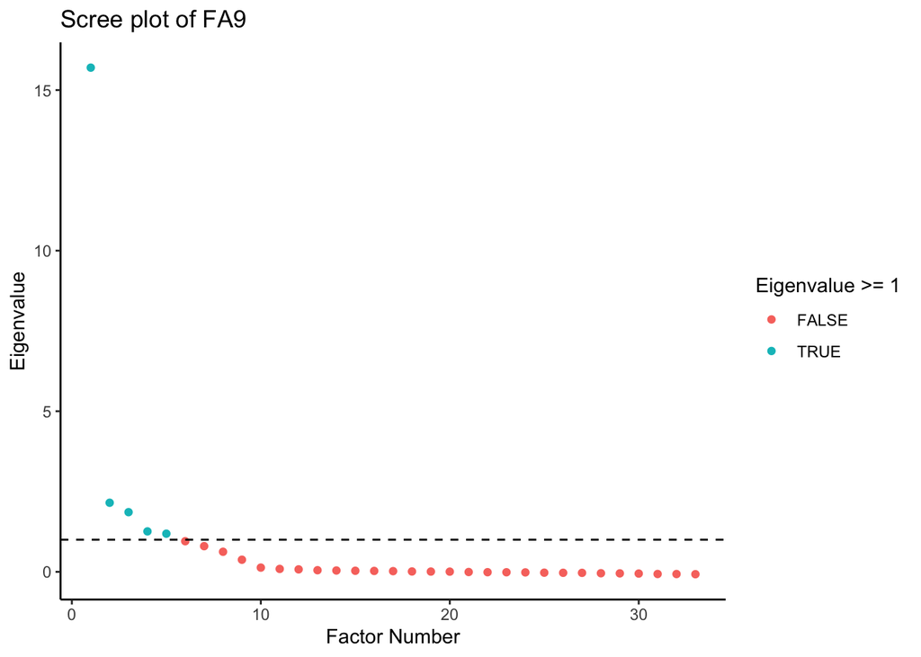

```r
ggplot(mapping = aes(x = 1:length(FA9$values),
                     y = FA9$values,
                     color = (FA9$values >= 1))) +
  geom_point() +
  geom_hline(yintercept = 1, linetype = "dashed") +
  theme_classic() +
  labs(title = "Scree plot of FA9",
       x = "Factor Number",
       y = "Eigenvalue",
       color = "Eigenvalue >= 1")
```

If we would only select based on the eigenvalues bigger than 1, then our model would have only 5 factors. However, due to all our previous analysis, this does not seem to be the best choice. The elbow rule would probably cut at 8 factors for `FA8_423`, as there is a bigger gap between 8 and 9. However, `FA9` does not have such a gap and the descent is quite smooth, so it is more difficult to determine.

## 1.4 Decide on a final principal factor analysis solution.

After reviewing all the information we gathered about our model, we decide to keep `FA8_423` over `FA9`.

Questions 4 and 23 Showed very little correlation with each other and even if they should theoretically represent the same construct of distinctiveness and prestige, the construct was not explored enough through questions in the survey. Every other construct had between 3 and 5 questions and the questions exhibit high correlations when they are in the same group.

Furthermore, the BIC is lowest for 8 factors and starts slowly rising again once we get past 8. The loadings of `qd4` and `qd23` in the `FA9` model remain lower than all other loadings of items inside their construct, being even lower than 0.5. When we looked at the anti-image correlation matrix diagonal, the proportions of unique variance in questions 4 and 23 were dominating the rest, indicating that the rest of the data set cannot explain most of their variance. Moreoever, their communalities were very low in `FA9`.

These reasons combined made us choose model `FA8_423`. Its constructs are the ones we listed when we inspected the correlation matrix (except of course the constructs of questions 4 and 23). The loading patterns of `FA8_423`, as we discussed in the previous point, are clear.

## 1.5 Run a principal component analysis (PCA) and compare the results.

Like with PAF, we run models with number of components ranging from 1 to 33 and will examine some criteria to get an idea of which ones best fit our data.

For PCA, the criteria are:

- `fit`, which measures how well the components model reproduces the correlation matrix;
- `fit.off`, which measures how well the off-diagonal elements of the correlation matrix are reproduced;
- `objective`, which is the value of the function that is minimized by a maximum likelihood procedure;
- `rms`, which is the sum of the squared off-diagonal residuals divided by the degrees of freedom.

```r
# we initiate and empty dataframe which will record our criteria values
fit_df <- matrix(nrow = 33, ncol = 4)
colnames(fit_df) <- c("fit", "fit.off", "objective", "rms")
fit_df <- as.data.frame(fit_df)

# we compute the factor analysis for nfactors between 1 and 13 and record criteria results in fit_df
for (i in 1:33) {
  PCA <- principal(df1, nfactors = i, rotate = "varimax")
  fit_df[i, 1] <- PCA$fit
  fit_df[i, 2] <- PCA$fit.off
  fit_df[i, 3] <- PCA$objective
  fit_df[i, 4] <- PCA$rms
}

rm(i, PCA)
```

We plot the results like before.

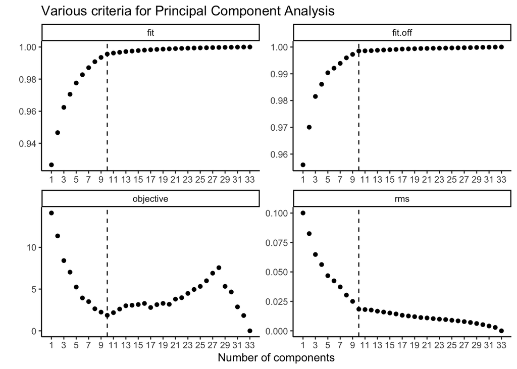

```r
fit_df %>% gather() %>%
  ggplot(aes(x = rep(1:33, ncol(fit_df)), y = value)) +
  facet_wrap(~ key, scales = "free") +
  geom_point() +
  theme_classic() +
  scale_x_continuous(breaks = seq(1, 33, 2)) +
  geom_vline(xintercept = 10, linetype = "dashed") +
  labs(title = "Various criteria for Principal Component Analysis",
       x = "Number of components",
       y = "")
```

Here, the ideal number of components seems to be 10, indicated by a dashed line. It is a local minimum of the objective function and is at thw elbow of the other three curves.

However, we check if this result would vary by omitting standalone variables `qd4` and `qd23`.

```r
# we initiate and empty dataframe which will record our criteria values
fit_df <- matrix(nrow = 31, ncol = 4)
colnames(fit_df) <- c("fit", "fit.off", "objective", "rms")
fit_df <- as.data.frame(fit_df)

# we compute the factor analysis for nfactors between 1 and 13 and record criteria results in fit_df
for (i in 1:31) {
  PCA <- principal(df1[, -c(4,23)], nfactors = i, rotate = "varimax")
  fit_df[i, 1] <- PCA$fit
  fit_df[i, 2] <- PCA$fit.off
  fit_df[i, 3] <- PCA$objective
  fit_df[i, 4] <- PCA$rms
}

rm(i, PCA)
```

Again, we plot the evolution of the criteria.

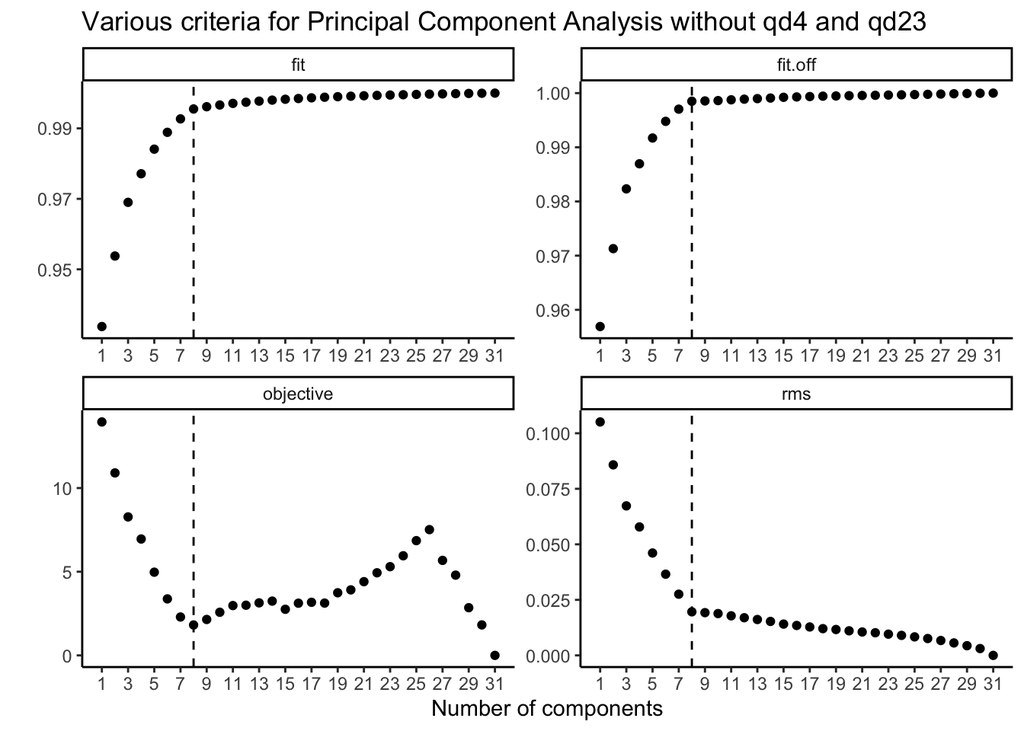

```r
fit_df %>% gather() %>%
  ggplot(aes(x = rep(1:31, ncol(fit_df)), y = value)) +
  facet_wrap(~ key, scales = "free") +
  geom_point() +
  theme_classic() +
  scale_x_continuous(breaks = seq(1, 31, 2)) +
  geom_vline(xintercept = 8, linetype = "dashed") +
  labs(title = "Various criteria for Principal Component Analysis without qd4 and qd23",
       x = "Number of components",
       y = "")
```

Without questions 4 and 23, the best model seems to be the one with 8 components.

Thus, we will test these two models.

```r
PCA <- principal(df1[, -c(4, 23)], nfactors = 8, rotate = "varimax")
sort(PCA$communality)
```

```
##      qd16      qd18       qd8      qd26       qd5      qd31      qd28      qd30
## 0.7281547 0.7417442 0.7445806 0.7696596 0.7781026 0.7916366 0.8042188 0.8142034
##      qd11      qd12      qd21       qd3       qd2      qd13      qd25       qd7
## 0.8172090 0.8230745 0.8252227 0.8320578 0.8362610 0.8401490 0.8514445 0.8541838
##      qd33       qd6       qd9      qd10      qd19      qd27      qd20      qd29
## 0.8570641 0.8581700 0.8717486 0.8732182 0.8739140 0.8771753 0.8792219 0.8799137
##      qd14      qd32       qd1      qd22      qd24      qd17      qd15
## 0.8809326 0.8882966 0.8907906 0.8911649 0.8980463 0.9009975 0.9012585
```

```r
# print(PCA$loadings, cutoff = 0.3, sort = TRUE)
PCA <- principal(df1, nfactors = 10, rotate = "varimax")
sort(PCA$communality)
```

```
##      qd16      qd18       qd8      qd26       qd5      qd31      qd28      qd30
## 0.7283694 0.7516579 0.7530489 0.7708933 0.7800535 0.7916076 0.8055633 0.8154692
##      qd11      qd12      qd21       qd3       qd2      qd13       qd7      qd25
## 0.8173072 0.8235556 0.8254960 0.8325685 0.8363938 0.8418185 0.8548721 0.8549029
##      qd33       qd6       qd9      qd10      qd19      qd27      qd29      qd20
## 0.8571892 0.8608017 0.8717715 0.8735724 0.8741658 0.8785617 0.8801344 0.8802786
##      qd14      qd32       qd1      qd22      qd24      qd17      qd15      qd23
## 0.8810422 0.8879448 0.8910183 0.8921397 0.8982019 0.9010692 0.9017948 0.9911283
##       qd4
## 0.9965632
```

```r
# print(PCA$loadings, cutoff = 0.3, sort = TRUE)
```

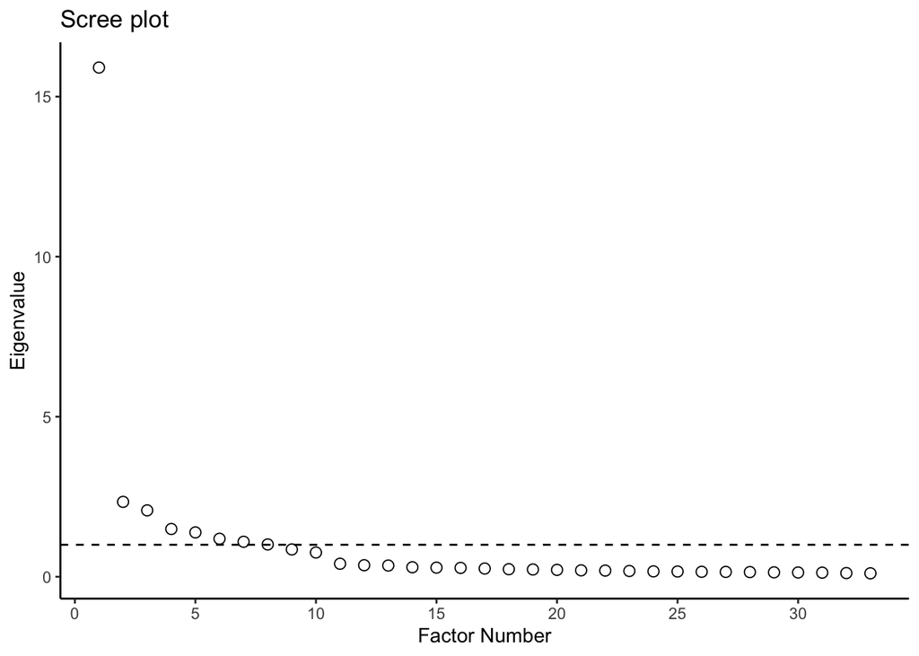

```r
PC0 <- principal(df1, rotate="varimax", scores=TRUE)

ggplot(mapping = aes(x = 1:33, y = PC0$values)) +
  geom_point(shape = 1, size = 2.5) +
  geom_hline(yintercept = 1, linetype = "dashed") +
  theme_classic() +
  scale_x_continuous(breaks = seq(0, 33, 5)) +
  labs(x = "Factor Number",
       y = "Eigenvalue",
       title = "Scree plot")
```

We have 8 eigenvalues which are bigger than 1. Thus, we redo a principal components analysis with 8 factors.

The Eigenvalues are plotted above, the horizontal line represents the significance threshold. After the first value there is a very steep drop, followed by a slower decline. The point above the significance level(and above the “elbow”) are around 7 or 8.

We attempt at retaining 8 factors:

```r
PC1 <- principal(df1, rotate="varimax", nfactors=8, scores=TRUE)
PC1_communalities=data.frame(sort(PC1$communality))
PC1_communalities %>% kbl()
```

|  | sort.PC1.communality. |
| --- | --- |
| qd23 | 0.5482221 |
| qd28 | 0.6110891 |
| qd26 | 0.6253977 |
| qd31 | 0.6812121 |
| qd4 | 0.6860378 |
| qd16 | 0.7228627 |
| qd8 | 0.7472794 |
| qd18 | 0.7489624 |
| qd5 | 0.7758762 |
| qd17 | 0.7983085 |
| qd32 | 0.7991891 |
| qd11 | 0.8061080 |
| qd12 | 0.8124165 |
| qd30 | 0.8130471 |
| qd15 | 0.8143803 |
| qd21 | 0.8251173 |
| qd3 | 0.8318214 |
| qd2 | 0.8341482 |
| qd13 | 0.8381954 |
| qd25 | 0.8392376 |
| qd7 | 0.8480460 |
| qd33 | 0.8514121 |
| qd6 | 0.8526109 |
| qd10 | 0.8693608 |
| qd9 | 0.8712220 |
| qd29 | 0.8731078 |
| qd19 | 0.8735513 |
| qd20 | 0.8750159 |
| qd27 | 0.8756005 |
| qd14 | 0.8803126 |
| qd1 | 0.8806015 |
| qd22 | 0.8835707 |
| qd24 | 0.8966449 |

We print out the communalities (sum of squared factor loadings for each variable) for all the variables, sorted in ascending order. The communality of a variable describes how much each factor, out of the extracted 8, contributes/explains the variance of this variable. So if the communality equals 1 then a complete replication of the variable can me obtained through the sole use of factors. In our case all variables have communalities below 1, so there is part of the variance that cannot be explained/modelled through factors. The lowest communalities are qd23,qd26,qd28.

As previously done, we utilized the “varimax” rotation, which is designed to simplify the interpretation of the loadings. “Simplification of factors: maximize variance of squared factor loadings; when loadings close to 0 or close to 1, factor becomes easier to interpret.”

## 1.6 Exploratory principal component analysis

#### 1.6.0.1 Principal Axis Factor Analysis:

PAF is an exploratory factor analysis method (or Factor Extraction Method), it attempts to find the least number of factors accounting for common variance of a set of variables. It uses a reduced correlation matrix, with a diagonal containing communalities (covariances).

It assumes that the variance of the observed variables cannot be fully explained by the extracted factors, it decomposes the variance in communality and unique variance, without accounting for specific and error variability.

```r
# printing out the communalities
PC1$communality %>% kbl()
```

|  | x |
| --- | --- |
| qd1 | 0.8806015 |
| qd2 | 0.8341482 |
| qd3 | 0.8318214 |
| qd4 | 0.6860378 |
| qd5 | 0.7758762 |
| qd6 | 0.8526109 |
| qd7 | 0.8480460 |
| qd8 | 0.7472794 |
| qd9 | 0.8712220 |
| qd10 | 0.8693608 |
| qd11 | 0.8061080 |
| qd12 | 0.8124165 |
| qd13 | 0.8381954 |
| qd14 | 0.8803126 |
| qd15 | 0.8143803 |
| qd16 | 0.7228627 |
| qd17 | 0.7983085 |
| qd18 | 0.7489624 |
| qd19 | 0.8735513 |
| qd20 | 0.8750159 |
| qd21 | 0.8251173 |
| qd22 | 0.8835707 |
| qd23 | 0.5482221 |
| qd24 | 0.8966449 |
| qd25 | 0.8392376 |
| qd26 | 0.6253977 |
| qd27 | 0.8756005 |
| qd28 | 0.6110891 |
| qd29 | 0.8731078 |
| qd30 | 0.8130471 |
| qd31 | 0.6812121 |
| qd32 | 0.7991891 |
| qd33 | 0.8514121 |

There seem to be no variables with incredibly low communality measure, qd23 is slightly above 0.5, but it is not worrying in itself.

#### 1.6.0.2 total variance explained

*I honeslty have no clue where this is going sorry*

```r
EigenValue=PC1$values
Variance=EigenValue/ncol(subset(df1))*100
SumVariance=cumsum(EigenValue/ncol(subset(df1)))
Total_Variance_Explained=cbind(EigenValue=EigenValue[EigenValue>0],Variance=Variance[Variance>0],Total_Variance=SumVariance[Variance>0])
Total_Variance_Explained
```

```
##       EigenValue   Variance Total_Variance
##  [1,] 15.9082244 48.2067407      0.4820674
##  [2,]  2.3398002  7.0903037      0.5529704
##  [3,]  2.0741379  6.2852665      0.6158231
##  [4,]  1.4922324  4.5219164      0.6610423
##  [5,]  1.3853335  4.1979804      0.7030221
##  [6,]  1.1868699  3.5965755      0.7389878
##  [7,]  1.0936900  3.3142121      0.7721300
##  [8,]  1.0096776  3.0596291      0.8027262
##  [9,]  0.8530507  2.5850023      0.8285763
## [10,]  0.7579386  2.2967837      0.8515441
## [11,]  0.4066927  1.2324022      0.8638681
## [12,]  0.3605823  1.0926736      0.8747949
## [13,]  0.3509690  1.0635424      0.8854303
## [14,]  0.2970630  0.9001911      0.8944322
```

[output cut: 19 more lines]

Total Variance:

$\begin{aligned}s^2_j&=1=h^2_j+c^2_j+e^2_j\\&=communality+specificity+measurament error\\&=h^2_j+d^2_j\\&=(1-d^2_j)+(c^2_j+e^2_j)\\&= communality+uniqueness\end{aligned}$

The 8 factors explain about 80% of the total variance in the data.

#### 1.6.0.3 Loadings for all variables:

$Loadings= Eigenvectors\times\sqrt{Eigenvalues}$ The loadings measure the correlation between the variables and the factors. Their signs indicated the direction of the relationship with the factors, the values the strength of such relationship.

```r
print(PC1$loadings, cutoff=0.3,sort=TRUE)
```

```
##
## Loadings:
##      RC2    RC1    RC7    RC5    RC4    RC8    RC3    RC6
## qd9   0.847
## qd14  0.868
## qd19  0.851
## qd21  0.823
## qd24  0.868
## qd2          0.758
## qd5          0.700
## qd7          0.755
## qd12         0.742
## qd16         0.703
## qd15                0.768
## qd17                0.740
## qd26                0.597                       0.322
## qd28         0.339  0.590
## qd31                0.692
## qd32                0.720  0.309
## qd1                        0.816
## qd10                       0.776
## qd20                       0.801
## qd27                       0.778
## qd3                               0.806
## qd11                              0.812
## qd13                              0.760
## qd30                              0.706
## qd6                                      0.752
## qd8          0.349                       0.620
## qd18                                     0.700
## qd25                                     0.791
## qd22                                            0.849
## qd29                                            0.836
## qd33                                            0.838
## qd4                                                    0.805
## qd23                                                   0.677
##
##                  RC2   RC1   RC7   RC5   RC4   RC8   RC3   RC6
## SS loadings    4.682 3.973 3.931 3.544 3.306 2.952 2.862 1.240
## Proportion Var 0.142 0.120 0.119 0.107 0.100 0.089 0.087 0.038
## Cumulative Var 0.142 0.262 0.381 0.489 0.589 0.678 0.765 0.803
```

```r
# so here she looks at like the ones that are not in patterns
# than se confronts it with the communalities and from there she decides which ones to eliminate
```

#### 1.6.0.5 Principal Analysis with filtered variables:

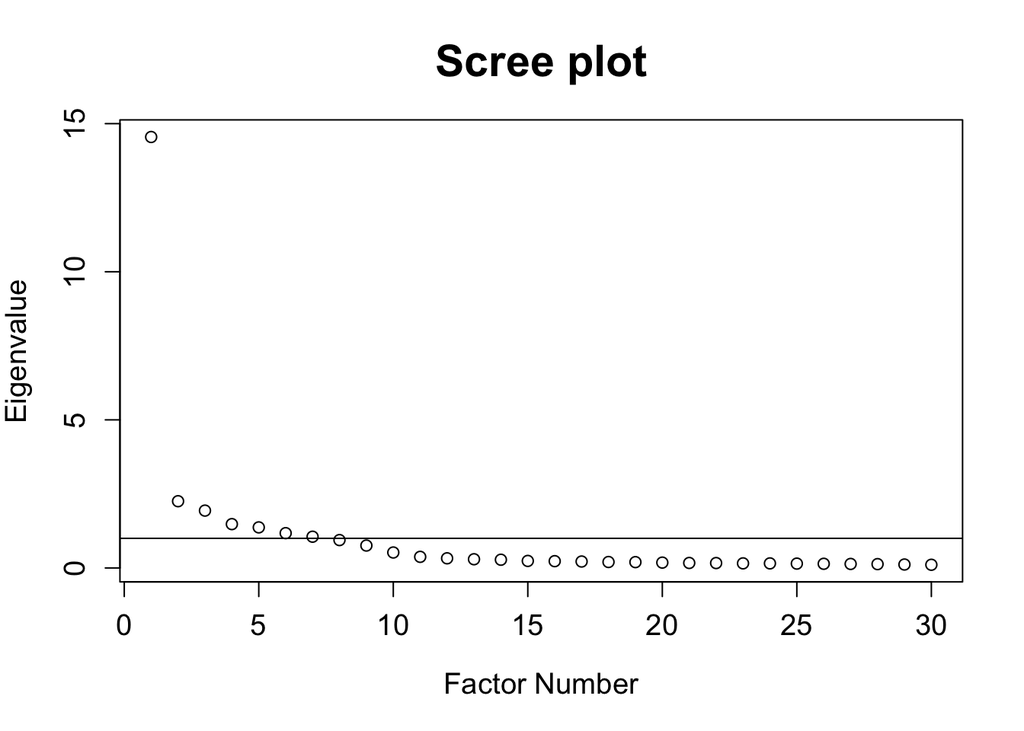

```
## integer(0)
```

```r
PC2 <- psych::principal(subset(df1, select = c(qd1:qd7,qd9:qd25,qd27,qd29:qd33)), rotate="varimax", scores=TRUE)

plot(PC2$values,xlab="Factor Number",ylab="Eigenvalue",main="Scree plot",cex.lab=1.2,cex.axis=1.2,cex.main=1.8)+abline(h=1)
```

```r
#idk if we should changed the names
# maybe even find a function that does this on its own
EigenValue=PC2$values
Variance=EigenValue/ncol(subset(df1, select = c(qd1:qd7,qd9:qd25,qd27,qd29:qd33)))*100
SumVariance=cumsum(EigenValue/ncol(subset(df1, select = c(qd1:qd7,qd9:qd25,qd27,qd29:qd33))))
Total_Variance_Explained2=cbind(EigenValue=EigenValue[EigenValue>0],Variance=Variance[Variance>0],Total_Variance=SumVariance[Variance>0])
Total_Variance_Explained2
```

```
##       EigenValue   Variance Total_Variance
##  [1,] 14.5494385 48.4981285      0.4849813
##  [2,]  2.2535415  7.5118050      0.5600993
##  [3,]  1.9361394  6.4537981      0.6246373
##  [4,]  1.4799762  4.9332541      0.6739699
##  [5,]  1.3703040  4.5676798      0.7196467
##  [6,]  1.1749996  3.9166654      0.7588133
##  [7,]  1.0554900  3.5183001      0.7939963
##  [8,]  0.9415073  3.1383578      0.8253799
##  [9,]  0.7570401  2.5234669      0.8506146
## [10,]  0.5222756  1.7409186      0.8680237
## [11,]  0.3752788  1.2509294      0.8805330
## [12,]  0.3258293  1.0860977      0.8913940
## [13,]  0.2942077  0.9806925      0.9012009
## [14,]  0.2781110  0.9270368      0.9104713
```

[output cut: 16 more lines]

we try between 6 and 7 to see if the loadings look better

```r
PC3_6 <- psych::principal(subset(df1, select = c(qd1:qd6,qd9:qd25,qd27:qd33)), rotate="varimax",nfactors=6, scores=TRUE)
print(PC3_6$loadings, cutoff=0.3,sort=TRUE)
```

```
##
## Loadings:
##      RC2    RC1    RC3    RC4    RC5    RC6
## qd9   0.856
## qd14  0.878
## qd19  0.860
## qd21  0.836
## qd24  0.878
## qd1          0.854
## qd10         0.822
## qd20         0.839
## qd27         0.805
## qd2          0.353  0.583  0.360
## qd5          0.378  0.547  0.365
## qd12         0.363  0.539  0.401
## qd22                0.815
## qd28                0.501         0.360
## qd29                0.808
## qd33                0.799
## qd3                        0.811
## qd11                       0.812
## qd13                       0.770
## qd30                       0.721
## qd15                0.309         0.745
## qd17                              0.710
## qd31                0.453         0.530
## qd32         0.306                0.719
## qd4                                      0.584
## qd23                                     0.656
## qd6          0.485  0.337  0.379         0.338
## qd16         0.377  0.492  0.344
## qd18         0.466         0.361         0.422
## qd25         0.453  0.341  0.321         0.363
##
##                  RC2   RC1   RC3   RC4   RC5   RC6
## SS loadings    4.846 4.684 4.560 4.026 2.775 1.582
## Proportion Var 0.162 0.156 0.152 0.134 0.092 0.053
## Cumulative Var 0.162 0.318 0.470 0.604 0.696 0.749
```

it does not look nice

The variance explained has increased to 83%.

```r
PC3 <- psych::principal(subset(df1, select = c(qd1:qd7,qd9:qd25,qd27,qd29:qd33)), rotate="varimax",nfactors=8, scores=TRUE)
print(PC3$loadings, cutoff=0.3,sort=TRUE)
```

```
##
## Loadings:
##      RC2    RC1    RC5    RC4    RC7    RC3    RC8    RC6
## qd9   0.851
## qd14  0.870
## qd19  0.855
## qd21  0.827
## qd24  0.872
## qd2          0.774
## qd5          0.718
## qd7          0.774
## qd12         0.762
## qd16         0.719
## qd1                 0.827
## qd10                0.781
## qd20                0.810
## qd27                0.777
## qd3                        0.809
## qd11                       0.823
## qd13                       0.766
## qd30                       0.710
## qd15                              0.815
## qd17                              0.794
## qd31                              0.534  0.348
## qd32                              0.776
## qd22                                     0.864
## qd29                                     0.851
## qd33                                     0.853
## qd6          0.317                              0.728
## qd18                                            0.710
## qd25                                            0.764
## qd4                                                    0.844
## qd23                                                   0.666
##
##                  RC2   RC1   RC5   RC4   RC7   RC3   RC8   RC6
## SS loadings    4.650 3.975 3.493 3.278 2.964 2.896 2.298 1.207
## Proportion Var 0.155 0.133 0.116 0.109 0.099 0.097 0.077 0.040
## Cumulative Var 0.155 0.288 0.404 0.513 0.612 0.709 0.785 0.825
```

We try and see if removing dq6 and qd31 helps:

```r
PC3_new <- psych::principal(subset(df1, select = c(qd1:qd5,qd7,qd9:qd25,qd27,qd29:qd30,qd32,qd33)), rotate="varimax",nfactors=8, scores=TRUE)
print(PC3_new$loadings, cutoff=0.3,sort=TRUE)
```

```
##
## Loadings:
##      RC2    RC1    RC5    RC4    RC3    RC7    RC6    RC8
## qd9   0.855
## qd14  0.874
## qd19  0.858
## qd21  0.831
## qd24  0.875
## qd2          0.783
## qd5          0.742
## qd7          0.791
## qd12         0.772
## qd16         0.736
## qd1                 0.841
## qd10                0.796
## qd20                0.821
## qd27                0.785
## qd3                        0.813
## qd11                       0.826
## qd13                       0.773
## qd30                       0.719
## qd22                              0.870
## qd29                              0.857
## qd33                              0.857
## qd15                                     0.810
## qd17                                     0.794
## qd32                                     0.777
## qd18         0.379  0.372                       0.531
## qd23                                            0.843
## qd4                                                    0.967
## qd25         0.403  0.354                       0.441
##
##                  RC2   RC1   RC5   RC4   RC3   RC7   RC6   RC8
## SS loadings    4.654 4.235 3.697 3.290 2.818 2.483 1.332 1.009
## Proportion Var 0.166 0.151 0.132 0.117 0.101 0.089 0.048 0.036
## Cumulative Var 0.166 0.317 0.449 0.567 0.668 0.756 0.804 0.840
```

### 1.6.1 1.1 Do all of the variables in your final solution show clear loading patterns?

### 1.6.2 1.2 For your final solution run a principal component analysis and compare the results. Are there differences to your solution based on principal axis factoring?

*i honestly do not get why she did this, its literally pc2 called different, even tho for ours looks we might need to rethink how many we are taking away* *do regression with factor scores???? do we even have a y?*

# 2 Oblique Factor Analysis

### 2.0.1 1.3 What do the eigenvalues of the factors/quality dimensions tell us about their relevance for repurchase behaviour?

### 2.0.2 Exercise 2: Oblique Factor Anlysis